# Cars analysis

### Dataset preprocessing

For this analysis, the collected data was filtered by price range (5000 to 60000 euros), fuel (only Benzine and Diesel), age (maximum 10 years) and driven kilometers (from 10000 to 200000).

The score for each car is calculated by taking into account both age and kilometers. Below is the distribution within the two fuel groups.

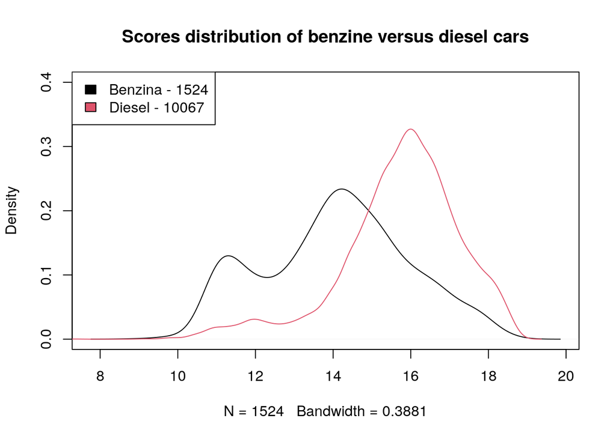

### Dataset composition

The following plots show the composition of the dataset, in terms of percentage of cars sold by dealers, year of matriculation and fuel versus emissions.

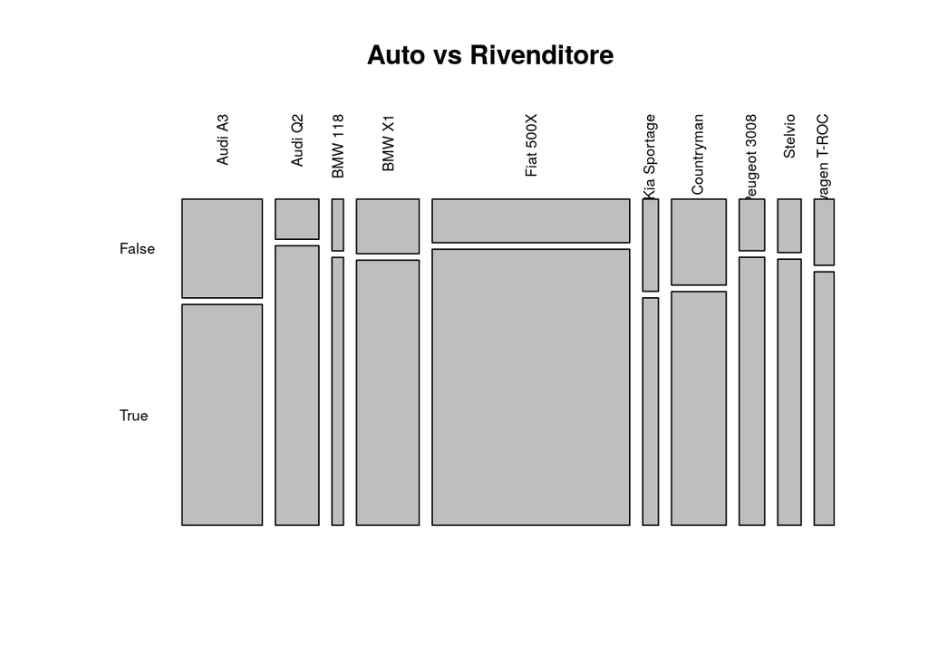

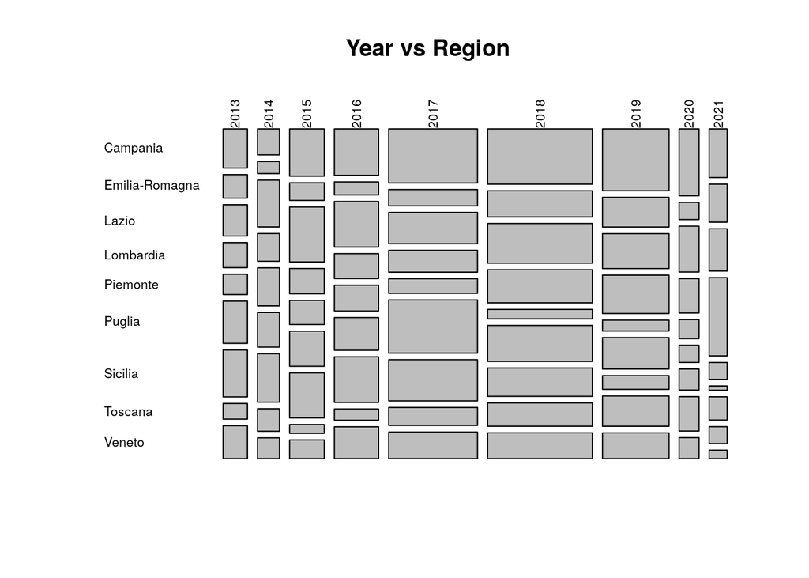

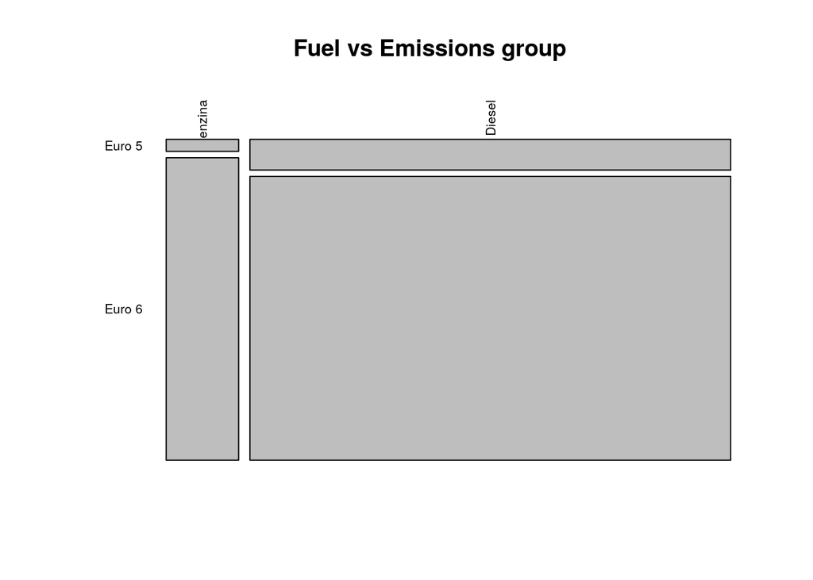

### Price distributions

The following boxplots show the price distribution across car models and Italian regions, while keeping the other variables fixed. Worth noticing are the different deviations from the median price across car models (i.e. higher ranges for BMW X1), as well as the differences in median prices according to the region where the same car is sold (i.e. higher prices in Lombardia).

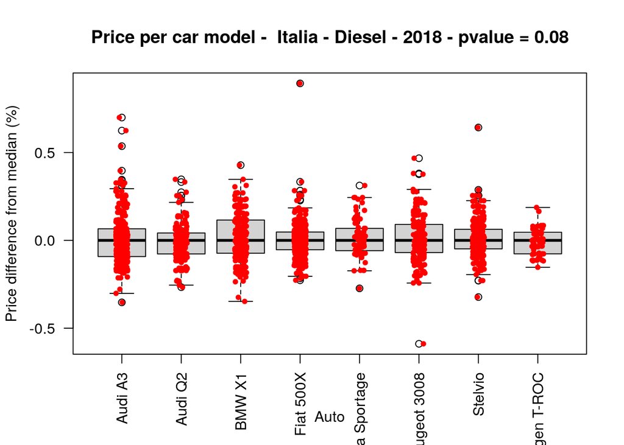

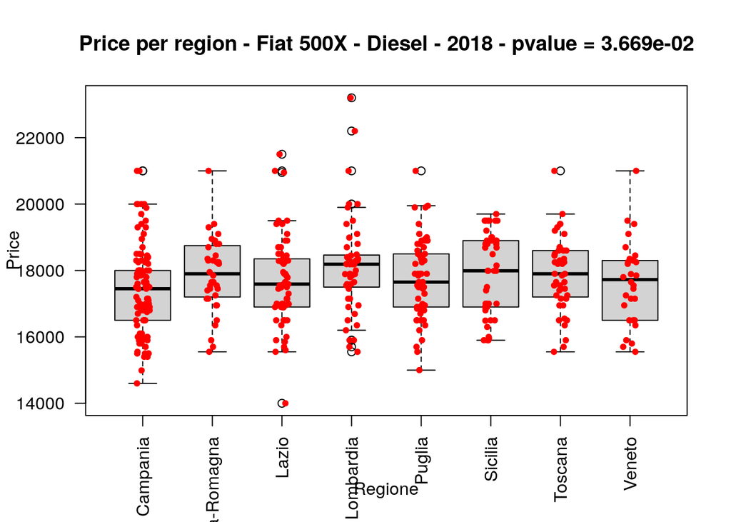

### Price devaluation over time and driven kilometers

The last analysis assess the slope of the devaluation of the price in order to infer a statistical model that can spot divergences from the general trend.

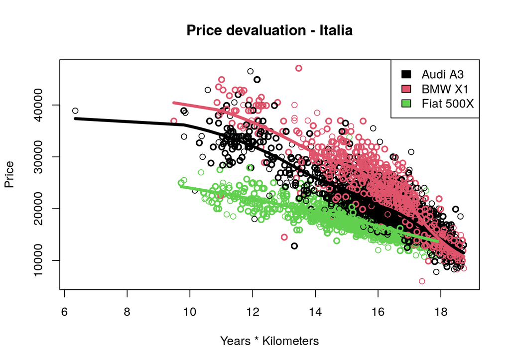

### List of convenient cars as predicted by the model

Ultimately, with these results we can spot occasions to buy. With a small donation we can provide you with the link and the details of the ads about your car interest!

| Prezzo | Auto | Immatricolazione | Kilometri | Alimentazione | Emissioni | Versione | Rivenditore | predicted_price |
| --- | --- | --- | --- | --- | --- | --- | --- | --- |
| 14.500 € | BMW X1 | 06/2020 | 35000 Km | Diesel | Euro 6 | X1 sDrive18d | True | 33794 |
| 22.490 € | BMW X1 | 01/2022 | 110000 Km | Diesel | Euro 6 | X1 sDrive18d Sport | True | 38878 |
| 12.800 € | Audi A3 | 04/2019 | 22500 Km | Diesel | Euro 6 | A3 SPB 30 TDI Sport | True | 28075 |
| 18.000 € | Audi A3 | 10/2020 | 21500 Km | Diesel | Euro 6 | C3 Aircross BlueHDi 100 S&amp;S Feel | False | 31896 |
| 23.500 € | Audi A3 | 02/2022 | 77000 Km | Diesel | Euro 6 | A3 1.6 TDI 116 CV Sport | False | 35682 |
| 6.000 € | BMW X1 | 09/2014 | 110000 Km | Diesel | Euro 5 | X1 sDrive16d | False | 17719 |
| 18.500 € | BMW X1 | 03/2019 | 54000 Km | Diesel | Euro 6 | Sportage 1.6 CRDI 115 CV 2WD Business Class | False | 29313 |
| 23.000 € | BMW X1 | 01/2020 | 39000 Km | Diesel | Euro 6 | X1 xDrive18d Sport | True | 32181 |
| 23.000 € | BMW X1 | 01/2020 | 39000 Km | Diesel | Euro 6 | X1 xDrive18d Sport | True | 32181 |
| 22.500 € | Audi A3 | 09/2019 | 15000 Km | Diesel | Euro 6 | A3 1.6 TDI 116 CV Business | False | 30627 |

[output cut: 5 more lines]